# Optimal Treatment Analysis

## Outcome Variable

**Outcome Variable:** ever_wasted

## Predictor Variables

**Intervention Variable:** mage

**Adjustment Set:**

- arm
- meducyrs
- feducyrs
- W_mhtcm
- single
- delta_meducyrs
- delta_feducyrs
- delta_W_mhtcm
- delta_single

## Stratifying Variables

The analysis was stratified on these variable(s):

- agecat
- studyid
- country

## Data Summary

| agecat | studyid | country | mage | ever_wasted | n_cell | n |
| --- | --- | --- | --- | --- | --- | --- |
| 0-24 months | ki0047075b-MAL-ED | BANGLADESH | [20-30) | 0 | 130 | 263 |
| 0-24 months | ki0047075b-MAL-ED | BANGLADESH | [20-30) | 1 | 50 | 263 |
| 0-24 months | ki0047075b-MAL-ED | BANGLADESH | <20 | 0 | 18 | 263 |
| 0-24 months | ki0047075b-MAL-ED | BANGLADESH | <20 | 1 | 19 | 263 |
| 0-24 months | ki0047075b-MAL-ED | BANGLADESH | >=30 | 0 | 28 | 263 |
| 0-24 months | ki0047075b-MAL-ED | BANGLADESH | >=30 | 1 | 18 | 263 |
| 0-24 months | ki0047075b-MAL-ED | BRAZIL | [20-30) | 0 | 127 | 233 |
| 0-24 months | ki0047075b-MAL-ED | BRAZIL | [20-30) | 1 | 12 | 233 |
| 0-24 months | ki0047075b-MAL-ED | BRAZIL | <20 | 0 | 40 | 233 |
| 0-24 months | ki0047075b-MAL-ED | BRAZIL | <20 | 1 | 3 | 233 |
| 0-24 months | ki0047075b-MAL-ED | BRAZIL | >=30 | 0 | 47 | 233 |
| 0-24 months | ki0047075b-MAL-ED | BRAZIL | >=30 | 1 | 4 | 233 |
| 0-24 months | ki0047075b-MAL-ED | INDIA | [20-30) | 0 | 102 | 249 |
| 0-24 months | ki0047075b-MAL-ED | INDIA | [20-30) | 1 | 92 | 249 |
| 0-24 months | ki0047075b-MAL-ED | INDIA | <20 | 0 | 15 | 249 |
| 0-24 months | ki0047075b-MAL-ED | INDIA | <20 | 1 | 19 | 249 |
| 0-24 months | ki0047075b-MAL-ED | INDIA | >=30 | 0 | 15 | 249 |
| 0-24 months | ki0047075b-MAL-ED | INDIA | >=30 | 1 | 6 | 249 |
| 0-24 months | ki0047075b-MAL-ED | NEPAL | [20-30) | 0 | 134 | 240 |
| 0-24 months | ki0047075b-MAL-ED | NEPAL | [20-30) | 1 | 55 | 240 |
| 0-24 months | ki0047075b-MAL-ED | NEPAL | <20 | 0 | 2 | 240 |
| 0-24 months | ki0047075b-MAL-ED | NEPAL | <20 | 1 | 3 | 240 |
| 0-24 months | ki0047075b-MAL-ED | NEPAL | >=30 | 0 | 35 | 240 |
| 0-24 months | ki0047075b-MAL-ED | NEPAL | >=30 | 1 | 11 | 240 |
| 0-24 months | ki0047075b-MAL-ED | PERU | [20-30) | 0 | 140 | 302 |
| 0-24 months | ki0047075b-MAL-ED | PERU | [20-30) | 1 | 13 | 302 |
| 0-24 months | ki0047075b-MAL-ED | PERU | <20 | 0 | 74 | 302 |
| 0-24 months | ki0047075b-MAL-ED | PERU | <20 | 1 | 8 | 302 |
| 0-24 months | ki0047075b-MAL-ED | PERU | >=30 | 0 | 62 | 302 |
| 0-24 months | ki0047075b-MAL-ED | PERU | >=30 | 1 | 5 | 302 |

[output cut: 450 more lines]

The following strata were considered:

- agecat: 0-24 months, studyid: ki0047075b-MAL-ED, country: BANGLADESH
- agecat: 0-24 months, studyid: ki0047075b-MAL-ED, country: BRAZIL
- agecat: 0-24 months, studyid: ki0047075b-MAL-ED, country: INDIA
- agecat: 0-24 months, studyid: ki0047075b-MAL-ED, country: NEPAL
- agecat: 0-24 months, studyid: ki0047075b-MAL-ED, country: PERU
- agecat: 0-24 months, studyid: ki0047075b-MAL-ED, country: SOUTH AFRICA
- agecat: 0-24 months, studyid: ki0047075b-MAL-ED, country: TANZANIA, UNITED REPUBLIC OF
- agecat: 0-24 months, studyid: ki1000108-CMC-V-BCS-2002, country: INDIA
- agecat: 0-24 months, studyid: ki1000108-IRC, country: INDIA
- agecat: 0-24 months, studyid: ki1000109-EE, country: PAKISTAN
- agecat: 0-24 months, studyid: ki1000304b-SAS-CompFeed, country: INDIA
- agecat: 0-24 months, studyid: ki1000304b-SAS-FoodSuppl, country: INDIA
- agecat: 0-24 months, studyid: ki1017093-NIH-Birth, country: BANGLADESH
- agecat: 0-24 months, studyid: ki1017093b-PROVIDE, country: BANGLADESH
- agecat: 0-24 months, studyid: ki1017093c-NIH-Crypto, country: BANGLADESH
- agecat: 0-24 months, studyid: ki1066203-TanzaniaChild2, country: TANZANIA, UNITED REPUBLIC OF
- agecat: 0-24 months, studyid: ki1101329-Keneba, country: GAMBIA
- agecat: 0-24 months, studyid: ki1112895-Guatemala BSC, country: GUATEMALA
- agecat: 0-24 months, studyid: ki1112895-iLiNS-Zinc, country: BURKINA FASO
- agecat: 0-24 months, studyid: ki1113344-GMS-Nepal, country: NEPAL
- agecat: 0-24 months, studyid: ki1119695-PROBIT, country: BELARUS
- agecat: 0-24 months, studyid: ki1126311-ZVITAMBO, country: ZIMBABWE
- agecat: 0-24 months, studyid: ki1135781-COHORTS, country: GUATEMALA
- agecat: 0-24 months, studyid: ki1135781-COHORTS, country: INDIA
- agecat: 0-24 months, studyid: ki1135781-COHORTS, country: PHILIPPINES
- agecat: 0-24 months, studyid: ki1148112-LCNI-5, country: MALAWI
- agecat: 0-24 months, studyid: kiGH5241-JiVitA-3, country: BANGLADESH
- agecat: 0-6 months, studyid: ki0047075b-MAL-ED, country: BANGLADESH
- agecat: 0-6 months, studyid: ki0047075b-MAL-ED, country: BRAZIL
- agecat: 0-6 months, studyid: ki0047075b-MAL-ED, country: INDIA
- agecat: 0-6 months, studyid: ki0047075b-MAL-ED, country: NEPAL
- agecat: 0-6 months, studyid: ki0047075b-MAL-ED, country: PERU
- agecat: 0-6 months, studyid: ki0047075b-MAL-ED, country: SOUTH AFRICA
- agecat: 0-6 months, studyid: ki0047075b-MAL-ED, country: TANZANIA, UNITED REPUBLIC OF
- agecat: 0-6 months, studyid: ki1000108-CMC-V-BCS-2002, country: INDIA
- agecat: 0-6 months, studyid: ki1000108-IRC, country: INDIA
- agecat: 0-6 months, studyid: ki1000109-EE, country: PAKISTAN
- agecat: 0-6 months, studyid: ki1000304b-SAS-CompFeed, country: INDIA
- agecat: 0-6 months, studyid: ki1000304b-SAS-FoodSuppl, country: INDIA
- agecat: 0-6 months, studyid: ki1017093-NIH-Birth, country: BANGLADESH
- agecat: 0-6 months, studyid: ki1017093b-PROVIDE, country: BANGLADESH
- agecat: 0-6 months, studyid: ki1017093c-NIH-Crypto, country: BANGLADESH
- agecat: 0-6 months, studyid: ki1066203-TanzaniaChild2, country: TANZANIA, UNITED REPUBLIC OF
- agecat: 0-6 months, studyid: ki1101329-Keneba, country: GAMBIA
- agecat: 0-6 months, studyid: ki1112895-Guatemala BSC, country: GUATEMALA
- agecat: 0-6 months, studyid: ki1113344-GMS-Nepal, country: NEPAL
- agecat: 0-6 months, studyid: ki1119695-PROBIT, country: BELARUS
- agecat: 0-6 months, studyid: ki1126311-ZVITAMBO, country: ZIMBABWE
- agecat: 0-6 months, studyid: ki1135781-COHORTS, country: GUATEMALA
- agecat: 0-6 months, studyid: ki1135781-COHORTS, country: INDIA
- agecat: 0-6 months, studyid: ki1135781-COHORTS, country: PHILIPPINES
- agecat: 0-6 months, studyid: ki1148112-LCNI-5, country: MALAWI
- agecat: 0-6 months, studyid: kiGH5241-JiVitA-3, country: BANGLADESH
- agecat: 6-24 months, studyid: ki0047075b-MAL-ED, country: BANGLADESH
- agecat: 6-24 months, studyid: ki0047075b-MAL-ED, country: BRAZIL
- agecat: 6-24 months, studyid: ki0047075b-MAL-ED, country: INDIA
- agecat: 6-24 months, studyid: ki0047075b-MAL-ED, country: NEPAL
- agecat: 6-24 months, studyid: ki0047075b-MAL-ED, country: PERU
- agecat: 6-24 months, studyid: ki0047075b-MAL-ED, country: SOUTH AFRICA
- agecat: 6-24 months, studyid: ki0047075b-MAL-ED, country: TANZANIA, UNITED REPUBLIC OF
- agecat: 6-24 months, studyid: ki1000108-CMC-V-BCS-2002, country: INDIA
- agecat: 6-24 months, studyid: ki1000108-IRC, country: INDIA
- agecat: 6-24 months, studyid: ki1000109-EE, country: PAKISTAN
- agecat: 6-24 months, studyid: ki1000304b-SAS-CompFeed, country: INDIA
- agecat: 6-24 months, studyid: ki1000304b-SAS-FoodSuppl, country: INDIA
- agecat: 6-24 months, studyid: ki1017093-NIH-Birth, country: BANGLADESH
- agecat: 6-24 months, studyid: ki1017093b-PROVIDE, country: BANGLADESH
- agecat: 6-24 months, studyid: ki1017093c-NIH-Crypto, country: BANGLADESH
- agecat: 6-24 months, studyid: ki1066203-TanzaniaChild2, country: TANZANIA, UNITED REPUBLIC OF
- agecat: 6-24 months, studyid: ki1101329-Keneba, country: GAMBIA
- agecat: 6-24 months, studyid: ki1112895-Guatemala BSC, country: GUATEMALA
- agecat: 6-24 months, studyid: ki1112895-iLiNS-Zinc, country: BURKINA FASO
- agecat: 6-24 months, studyid: ki1113344-GMS-Nepal, country: NEPAL
- agecat: 6-24 months, studyid: ki1119695-PROBIT, country: BELARUS
- agecat: 6-24 months, studyid: ki1126311-ZVITAMBO, country: ZIMBABWE
- agecat: 6-24 months, studyid: ki1135781-COHORTS, country: GUATEMALA
- agecat: 6-24 months, studyid: ki1135781-COHORTS, country: INDIA
- agecat: 6-24 months, studyid: ki1135781-COHORTS, country: PHILIPPINES
- agecat: 6-24 months, studyid: ki1148112-LCNI-5, country: MALAWI
- agecat: 6-24 months, studyid: kiGH5241-JiVitA-3, country: BANGLADESH

### Dropped Strata

Some strata were dropped due to rare outcomes:

- agecat: 0-24 months, studyid: ki0047075b-MAL-ED, country: BRAZIL
- agecat: 0-24 months, studyid: ki0047075b-MAL-ED, country: NEPAL
- agecat: 0-24 months, studyid: ki0047075b-MAL-ED, country: TANZANIA, UNITED REPUBLIC OF
- agecat: 0-24 months, studyid: ki1000109-EE, country: PAKISTAN
- agecat: 0-24 months, studyid: ki1000304b-SAS-FoodSuppl, country: INDIA
- agecat: 0-6 months, studyid: ki0047075b-MAL-ED, country: BRAZIL
- agecat: 0-6 months, studyid: ki0047075b-MAL-ED, country: NEPAL
- agecat: 0-6 months, studyid: ki0047075b-MAL-ED, country: PERU
- agecat: 0-6 months, studyid: ki0047075b-MAL-ED, country: TANZANIA, UNITED REPUBLIC OF
- agecat: 0-6 months, studyid: ki1000109-EE, country: PAKISTAN
- agecat: 0-6 months, studyid: ki1000304b-SAS-FoodSuppl, country: INDIA
- agecat: 0-6 months, studyid: ki1112895-Guatemala BSC, country: GUATEMALA
- agecat: 0-6 months, studyid: ki1148112-LCNI-5, country: MALAWI
- agecat: 6-24 months, studyid: ki0047075b-MAL-ED, country: BRAZIL
- agecat: 6-24 months, studyid: ki0047075b-MAL-ED, country: INDIA
- agecat: 6-24 months, studyid: ki0047075b-MAL-ED, country: NEPAL
- agecat: 6-24 months, studyid: ki0047075b-MAL-ED, country: PERU
- agecat: 6-24 months, studyid: ki0047075b-MAL-ED, country: SOUTH AFRICA
- agecat: 6-24 months, studyid: ki0047075b-MAL-ED, country: TANZANIA, UNITED REPUBLIC OF
- agecat: 6-24 months, studyid: ki1000109-EE, country: PAKISTAN
- agecat: 6-24 months, studyid: ki1000304b-SAS-FoodSuppl, country: INDIA
- agecat: 6-24 months, studyid: ki1112895-Guatemala BSC, country: GUATEMALA

## Methods Detail

We’re interested in the causal parameters $E[Y_a]$ for all values of $a \in \mathcal{A}$. These parameters represent the mean outcome if, possibly contrary to fact, we intervened to set all units to have $A=a$. Under the randomization and positivity assumptions, these are identified by the statistical parameters $\psi_a=E_W[E_{Y|A,W}(Y|A=a,W)]$. In addition, we’re interested in the mean of $Y$, $E[Y]$ under no intervention (the observed mean). We will estimate these parameters by using SuperLearner to fit the relevant likelihood factors – $E_{Y|A,W}(Y|A=a,W)$ and $p(A=a|W)$, and then updating our likelihood fit using a joint TMLE.

For unadjusted analyses ($W=\{\}$), initial likelihoods were estimated using Lrnr_glm to estimate the simple $E(Y|A)$ and Lrnr_mean to estimate $p(A)$. For adjusted analyses, a small library containing Lrnr_glmnet, Lrnr_xgboost, and Lrnr_mean was used.

Having estimated these parameters, we will then use the delta method to estimate relative risks and attributable risks relative to a prespecified baseline level of $A$.

# Results Detail

## Results Plots

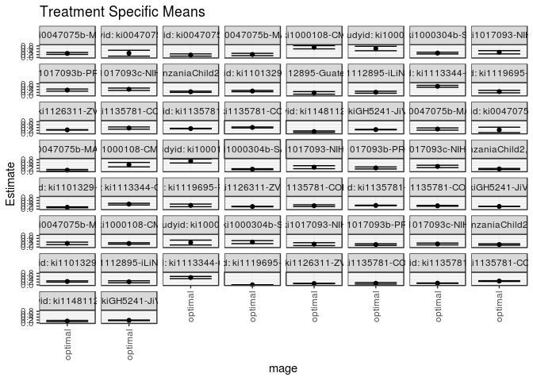

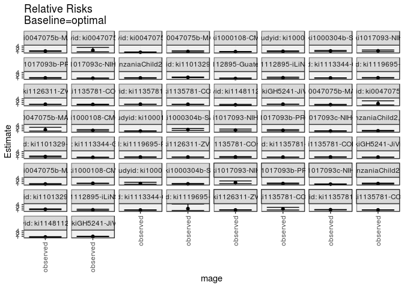

## Results Table

### Parameter: TSM

| agecat | studyid | country | intervention_level | baseline_level | estimate | ci_lower | ci_upper |
| --- | --- | --- | --- | --- | --- | --- | --- |
| 0-24 months | ki0047075b-MAL-ED | BANGLADESH | optimal | NA | 0.2780924 | 0.2123731 | 0.3438118 |
| 0-24 months | ki0047075b-MAL-ED | INDIA | optimal | NA | 0.2917055 | 0.0855619 | 0.4978490 |
| 0-24 months | ki0047075b-MAL-ED | PERU | optimal | NA | 0.1665648 | 0.0888751 | 0.2442545 |
| 0-24 months | ki0047075b-MAL-ED | SOUTH AFRICA | optimal | NA | 0.2025974 | 0.1197596 | 0.2854351 |
| 0-24 months | ki1000108-CMC-V-BCS-2002 | INDIA | optimal | NA | 0.7072912 | 0.5945801 | 0.8200024 |
| 0-24 months | ki1000108-IRC | INDIA | optimal | NA | 0.6183336 | 0.4637079 | 0.7729593 |
| 0-24 months | ki1000304b-SAS-CompFeed | INDIA | optimal | NA | 0.3006333 | 0.2420698 | 0.3591969 |
| 0-24 months | ki1017093-NIH-Birth | BANGLADESH | optimal | NA | 0.3575832 | 0.2448894 | 0.4702770 |
| 0-24 months | ki1017093b-PROVIDE | BANGLADESH | optimal | NA | 0.3633472 | 0.2902834 | 0.4364110 |
| 0-24 months | ki1017093c-NIH-Crypto | BANGLADESH | optimal | NA | 0.4213481 | 0.3385563 | 0.5041399 |
| 0-24 months | ki1066203-TanzaniaChild2 | TANZANIA, UNITED REPUBLIC OF | optimal | NA | 0.2478418 | 0.2075576 | 0.2881261 |
| 0-24 months | ki1101329-Keneba | GAMBIA | optimal | NA | 0.2968000 | 0.2515765 | 0.3420235 |
| 0-24 months | ki1112895-Guatemala BSC | GUATEMALA | optimal | NA | 0.1696608 | 0.0793354 | 0.2599862 |
| 0-24 months | ki1112895-iLiNS-Zinc | BURKINA FASO | optimal | NA | 0.2154300 | 0.1461364 | 0.2847236 |
| 0-24 months | ki1113344-GMS-Nepal | NEPAL | optimal | NA | 0.6279984 | 0.5602113 | 0.6957856 |
| 0-24 months | ki1119695-PROBIT | BELARUS | optimal | NA | 0.2589305 | 0.1728179 | 0.3450431 |
| 0-24 months | ki1126311-ZVITAMBO | ZIMBABWE | optimal | NA | 0.2328738 | 0.2178034 | 0.2479442 |
| 0-24 months | ki1135781-COHORTS | GUATEMALA | optimal | NA | 0.3607916 | 0.2847728 | 0.4368105 |
| 0-24 months | ki1135781-COHORTS | INDIA | optimal | NA | 0.3234023 | 0.3035669 | 0.3432377 |
| 0-24 months | ki1135781-COHORTS | PHILIPPINES | optimal | NA | 0.4038057 | 0.3716187 | 0.4359928 |
| 0-24 months | ki1148112-LCNI-5 | MALAWI | optimal | NA | 0.1149769 | 0.0665430 | 0.1634108 |
| 0-24 months | kiGH5241-JiVitA-3 | BANGLADESH | optimal | NA | 0.2535568 | 0.2377089 | 0.2694048 |
| 0-6 months | ki0047075b-MAL-ED | BANGLADESH | optimal | NA | 0.2926375 | 0.2150471 | 0.3702280 |
| 0-6 months | ki0047075b-MAL-ED | INDIA | optimal | NA | 0.2340907 | 0.0460253 | 0.4221561 |
| 0-6 months | ki0047075b-MAL-ED | SOUTH AFRICA | optimal | NA | 0.0675889 | 0.0185925 | 0.1165852 |
| 0-6 months | ki1000108-CMC-V-BCS-2002 | INDIA | optimal | NA | 0.4523016 | 0.2979689 | 0.6066342 |
| 0-6 months | ki1000108-IRC | INDIA | optimal | NA | 0.7042066 | 0.5660772 | 0.8423360 |
| 0-6 months | ki1000304b-SAS-CompFeed | INDIA | optimal | NA | 0.1386233 | 0.1092393 | 0.1680073 |
| 0-6 months | ki1017093-NIH-Birth | BANGLADESH | optimal | NA | 0.2748464 | 0.1685763 | 0.3811164 |
| 0-6 months | ki1017093b-PROVIDE | BANGLADESH | optimal | NA | 0.2228799 | 0.1528708 | 0.2928889 |
| 0-6 months | ki1017093c-NIH-Crypto | BANGLADESH | optimal | NA | 0.3296113 | 0.2462630 | 0.4129596 |
| 0-6 months | ki1066203-TanzaniaChild2 | TANZANIA, UNITED REPUBLIC OF | optimal | NA | 0.1520703 | 0.1151843 | 0.1889562 |
| 0-6 months | ki1101329-Keneba | GAMBIA | optimal | NA | 0.1250170 | 0.0948805 | 0.1551535 |
| 0-6 months | ki1113344-GMS-Nepal | NEPAL | optimal | NA | 0.3446881 | 0.2849786 | 0.4043976 |
| 0-6 months | ki1119695-PROBIT | BELARUS | optimal | NA | 0.2553939 | 0.1631106 | 0.3476773 |
| 0-6 months | ki1126311-ZVITAMBO | ZIMBABWE | optimal | NA | 0.1770662 | 0.1625549 | 0.1915775 |
| 0-6 months | ki1135781-COHORTS | GUATEMALA | optimal | NA | 0.2328566 | 0.1702627 | 0.2954505 |
| 0-6 months | ki1135781-COHORTS | INDIA | optimal | NA | 0.2522567 | 0.2340126 | 0.2705008 |
| 0-6 months | ki1135781-COHORTS | PHILIPPINES | optimal | NA | 0.2271254 | 0.1981974 | 0.2560535 |
| 0-6 months | kiGH5241-JiVitA-3 | BANGLADESH | optimal | NA | 0.1847322 | 0.1725630 | 0.1969014 |
| 6-24 months | ki0047075b-MAL-ED | BANGLADESH | optimal | NA | 0.2505844 | 0.1649407 | 0.3362281 |
| 6-24 months | ki1000108-CMC-V-BCS-2002 | INDIA | optimal | NA | 0.2437979 | 0.1947435 | 0.2928522 |
| 6-24 months | ki1000108-IRC | INDIA | optimal | NA | 0.3093739 | 0.1397716 | 0.4789762 |
| 6-24 months | ki1000304b-SAS-CompFeed | INDIA | optimal | NA | 0.3388872 | 0.2325461 | 0.4452282 |
| 6-24 months | ki1017093-NIH-Birth | BANGLADESH | optimal | NA | 0.1980233 | 0.0966253 | 0.2994214 |
| 6-24 months | ki1017093b-PROVIDE | BANGLADESH | optimal | NA | 0.1665238 | 0.1095091 | 0.2235385 |
| 6-24 months | ki1017093c-NIH-Crypto | BANGLADESH | optimal | NA | 0.2102338 | 0.1484621 | 0.2720055 |
| 6-24 months | ki1066203-TanzaniaChild2 | TANZANIA, UNITED REPUBLIC OF | optimal | NA | 0.1706293 | 0.1214815 | 0.2197772 |
| 6-24 months | ki1101329-Keneba | GAMBIA | optimal | NA | 0.2388572 | 0.1946617 | 0.2830527 |
| 6-24 months | ki1112895-iLiNS-Zinc | BURKINA FASO | optimal | NA | 0.2154300 | 0.1461364 | 0.2847236 |
| 6-24 months | ki1113344-GMS-Nepal | NEPAL | optimal | NA | 0.5123856 | 0.4355969 | 0.5891743 |
| 6-24 months | ki1119695-PROBIT | BELARUS | optimal | NA | 0.0048443 | 0.0005574 | 0.0091312 |
| 6-24 months | ki1126311-ZVITAMBO | ZIMBABWE | optimal | NA | 0.0967911 | 0.0850856 | 0.1084965 |
| 6-24 months | ki1135781-COHORTS | GUATEMALA | optimal | NA | 0.1130375 | 0.0570747 | 0.1690003 |
| 6-24 months | ki1135781-COHORTS | INDIA | optimal | NA | 0.1201125 | 0.1064528 | 0.1337723 |
| 6-24 months | ki1135781-COHORTS | PHILIPPINES | optimal | NA | 0.2678040 | 0.2418295 | 0.2937785 |
| 6-24 months | ki1148112-LCNI-5 | MALAWI | optimal | NA | 0.1238355 | 0.0779227 | 0.1697482 |
| 6-24 months | kiGH5241-JiVitA-3 | BANGLADESH | optimal | NA | 0.1730284 | 0.1516623 | 0.1943945 |

### Parameter: E(Y)

| agecat | studyid | country | intervention_level | baseline_level | estimate | ci_lower | ci_upper |
| --- | --- | --- | --- | --- | --- | --- | --- |
| 0-24 months | ki0047075b-MAL-ED | BANGLADESH | observed | NA | 0.3307985 | 0.2738270 | 0.3877700 |
| 0-24 months | ki0047075b-MAL-ED | INDIA | observed | NA | 0.4698795 | 0.4077636 | 0.5319954 |
| 0-24 months | ki0047075b-MAL-ED | PERU | observed | NA | 0.0860927 | 0.0544044 | 0.1177810 |
| 0-24 months | ki0047075b-MAL-ED | SOUTH AFRICA | observed | NA | 0.1955128 | 0.1514355 | 0.2395901 |
| 0-24 months | ki1000108-CMC-V-BCS-2002 | INDIA | observed | NA | 0.6139410 | 0.5644682 | 0.6634139 |
| 0-24 months | ki1000108-IRC | INDIA | observed | NA | 0.6560976 | 0.6100625 | 0.7021326 |
| 0-24 months | ki1000304b-SAS-CompFeed | INDIA | observed | NA | 0.3822894 | 0.3008363 | 0.4637425 |
| 0-24 months | ki1017093-NIH-Birth | BANGLADESH | observed | NA | 0.4774920 | 0.4382065 | 0.5167774 |
| 0-24 months | ki1017093b-PROVIDE | BANGLADESH | observed | NA | 0.3514286 | 0.3160364 | 0.3868207 |
| 0-24 months | ki1017093c-NIH-Crypto | BANGLADESH | observed | NA | 0.3311346 | 0.2976093 | 0.3646598 |
| 0-24 months | ki1066203-TanzaniaChild2 | TANZANIA, UNITED REPUBLIC OF | observed | NA | 0.2369529 | 0.2198518 | 0.2540539 |
| 0-24 months | ki1101329-Keneba | GAMBIA | observed | NA | 0.3789731 | 0.3611996 | 0.3967466 |
| 0-24 months | ki1112895-Guatemala BSC | GUATEMALA | observed | NA | 0.1067616 | 0.0705906 | 0.1429325 |
| 0-24 months | ki1112895-iLiNS-Zinc | BURKINA FASO | observed | NA | 0.2259307 | 0.1907517 | 0.2611097 |
| 0-24 months | ki1113344-GMS-Nepal | NEPAL | observed | NA | 0.5913621 | 0.5520608 | 0.6306634 |
| 0-24 months | ki1119695-PROBIT | BELARUS | observed | NA | 0.2655346 | 0.1719990 | 0.3590703 |
| 0-24 months | ki1126311-ZVITAMBO | ZIMBABWE | observed | NA | 0.2345874 | 0.2275431 | 0.2416318 |
| 0-24 months | ki1135781-COHORTS | GUATEMALA | observed | NA | 0.3216463 | 0.2858742 | 0.3574185 |
| 0-24 months | ki1135781-COHORTS | INDIA | observed | NA | 0.3359095 | 0.3231988 | 0.3486203 |
| 0-24 months | ki1135781-COHORTS | PHILIPPINES | observed | NA | 0.4036125 | 0.3861835 | 0.4210415 |
| 0-24 months | ki1148112-LCNI-5 | MALAWI | observed | NA | 0.0805970 | 0.0599695 | 0.1012246 |
| 0-24 months | kiGH5241-JiVitA-3 | BANGLADESH | observed | NA | 0.2643902 | 0.2553053 | 0.2734752 |
| 0-6 months | ki0047075b-MAL-ED | BANGLADESH | observed | NA | 0.2243346 | 0.1738240 | 0.2748452 |
| 0-6 months | ki0047075b-MAL-ED | INDIA | observed | NA | 0.3132530 | 0.2555274 | 0.3709786 |
| 0-6 months | ki0047075b-MAL-ED | SOUTH AFRICA | observed | NA | 0.1025641 | 0.0688457 | 0.1362825 |
| 0-6 months | ki1000108-CMC-V-BCS-2002 | INDIA | observed | NA | 0.5190217 | 0.4679041 | 0.5701394 |
| 0-6 months | ki1000108-IRC | INDIA | observed | NA | 0.5439024 | 0.4956326 | 0.5921723 |
| 0-6 months | ki1000304b-SAS-CompFeed | INDIA | observed | NA | 0.2207792 | 0.1636864 | 0.2778721 |
| 0-6 months | ki1017093-NIH-Birth | BANGLADESH | observed | NA | 0.3580645 | 0.3202961 | 0.3958330 |
| 0-6 months | ki1017093b-PROVIDE | BANGLADESH | observed | NA | 0.2585714 | 0.2261125 | 0.2910304 |
| 0-6 months | ki1017093c-NIH-Crypto | BANGLADESH | observed | NA | 0.2585752 | 0.2273844 | 0.2897660 |
| 0-6 months | ki1066203-TanzaniaChild2 | TANZANIA, UNITED REPUBLIC OF | observed | NA | 0.1397306 | 0.1257869 | 0.1536744 |
| 0-6 months | ki1101329-Keneba | GAMBIA | observed | NA | 0.1598344 | 0.1452161 | 0.1744527 |
| 0-6 months | ki1113344-GMS-Nepal | NEPAL | observed | NA | 0.2956811 | 0.2591967 | 0.3321655 |
| 0-6 months | ki1119695-PROBIT | BELARUS | observed | NA | 0.2599065 | 0.1654090 | 0.3544039 |
| 0-6 months | ki1126311-ZVITAMBO | ZIMBABWE | observed | NA | 0.1808241 | 0.1744046 | 0.1872436 |
| 0-6 months | ki1135781-COHORTS | GUATEMALA | observed | NA | 0.2485323 | 0.2110255 | 0.2860391 |
| 0-6 months | ki1135781-COHORTS | INDIA | observed | NA | 0.2500980 | 0.2382136 | 0.2619824 |
| 0-6 months | ki1135781-COHORTS | PHILIPPINES | observed | NA | 0.2355453 | 0.2204685 | 0.2506222 |
| 0-6 months | kiGH5241-JiVitA-3 | BANGLADESH | observed | NA | 0.1823591 | 0.1743561 | 0.1903622 |
| 6-24 months | ki0047075b-MAL-ED | BANGLADESH | observed | NA | 0.1833333 | 0.1342773 | 0.2323893 |
| 6-24 months | ki1000108-CMC-V-BCS-2002 | INDIA | observed | NA | 0.2654155 | 0.2205451 | 0.3102860 |
| 6-24 months | ki1000108-IRC | INDIA | observed | NA | 0.3097561 | 0.2649438 | 0.3545684 |
| 6-24 months | ki1000304b-SAS-CompFeed | INDIA | observed | NA | 0.2708333 | 0.2169112 | 0.3247555 |
| 6-24 months | ki1017093-NIH-Birth | BANGLADESH | observed | NA | 0.2931354 | 0.2546710 | 0.3315999 |
| 6-24 months | ki1017093b-PROVIDE | BANGLADESH | observed | NA | 0.1609756 | 0.1319065 | 0.1900447 |
| 6-24 months | ki1017093c-NIH-Crypto | BANGLADESH | observed | NA | 0.1315068 | 0.1069744 | 0.1560393 |
| 6-24 months | ki1066203-TanzaniaChild2 | TANZANIA, UNITED REPUBLIC OF | observed | NA | 0.1607589 | 0.1446692 | 0.1768485 |
| 6-24 months | ki1101329-Keneba | GAMBIA | observed | NA | 0.3205653 | 0.3029225 | 0.3382080 |
| 6-24 months | ki1112895-iLiNS-Zinc | BURKINA FASO | observed | NA | 0.2259307 | 0.1907517 | 0.2611097 |
| 6-24 months | ki1113344-GMS-Nepal | NEPAL | observed | NA | 0.4728814 | 0.4325613 | 0.5132014 |
| 6-24 months | ki1119695-PROBIT | BELARUS | observed | NA | 0.0082759 | 0.0065972 | 0.0099545 |
| 6-24 months | ki1126311-ZVITAMBO | ZIMBABWE | observed | NA | 0.0940195 | 0.0884810 | 0.0995580 |
| 6-24 months | ki1135781-COHORTS | GUATEMALA | observed | NA | 0.1731092 | 0.1426836 | 0.2035348 |
| 6-24 months | ki1135781-COHORTS | INDIA | observed | NA | 0.1317329 | 0.1223171 | 0.1411487 |
| 6-24 months | ki1135781-COHORTS | PHILIPPINES | observed | NA | 0.2666429 | 0.2502871 | 0.2829988 |
| 6-24 months | ki1148112-LCNI-5 | MALAWI | observed | NA | 0.0789074 | 0.0583085 | 0.0995064 |
| 6-24 months | kiGH5241-JiVitA-3 | BANGLADESH | observed | NA | 0.1652052 | 0.1560335 | 0.1743769 |

### Parameter: RR

| agecat | studyid | country | intervention_level | baseline_level | estimate | ci_lower | ci_upper |
| --- | --- | --- | --- | --- | --- | --- | --- |
| 0-24 months | ki0047075b-MAL-ED | BANGLADESH | observed | optimal | 1.1895271 | 1.0279631 | 1.3764840 |
| 0-24 months | ki0047075b-MAL-ED | INDIA | observed | optimal | 1.6108013 | 0.8126896 | 3.1927083 |
| 0-24 months | ki0047075b-MAL-ED | PERU | observed | optimal | 0.5168721 | 0.3605956 | 0.7408765 |
| 0-24 months | ki0047075b-MAL-ED | SOUTH AFRICA | observed | optimal | 0.9650314 | 0.6810994 | 1.3673270 |
| 0-24 months | ki1000108-CMC-V-BCS-2002 | INDIA | observed | optimal | 0.8680173 | 0.7474732 | 1.0080013 |
| 0-24 months | ki1000108-IRC | INDIA | observed | optimal | 1.0610738 | 0.8354337 | 1.3476563 |
| 0-24 months | ki1000304b-SAS-CompFeed | INDIA | observed | optimal | 1.2716136 | 1.0501536 | 1.5397757 |
| 0-24 months | ki1017093-NIH-Birth | BANGLADESH | observed | optimal | 1.3353312 | 0.9907697 | 1.7997214 |
| 0-24 months | ki1017093b-PROVIDE | BANGLADESH | observed | optimal | 0.9671977 | 0.8123733 | 1.1515291 |
| 0-24 months | ki1017093c-NIH-Crypto | BANGLADESH | observed | optimal | 0.7858931 | 0.6591337 | 0.9370297 |
| 0-24 months | ki1066203-TanzaniaChild2 | TANZANIA, UNITED REPUBLIC OF | observed | optimal | 0.9560649 | 0.8267675 | 1.1055829 |
| 0-24 months | ki1101329-Keneba | GAMBIA | observed | optimal | 1.2768637 | 1.1062790 | 1.4737520 |
| 0-24 months | ki1112895-Guatemala BSC | GUATEMALA | observed | optimal | 0.6292648 | 0.4231570 | 0.9357618 |
| 0-24 months | ki1112895-iLiNS-Zinc | BURKINA FASO | observed | optimal | 1.0487428 | 0.7776796 | 1.4142862 |
| 0-24 months | ki1113344-GMS-Nepal | NEPAL | observed | optimal | 0.9416618 | 0.8623451 | 1.0282739 |
| 0-24 months | ki1119695-PROBIT | BELARUS | observed | optimal | 1.0255054 | 0.9064230 | 1.1602324 |
| 0-24 months | ki1126311-ZVITAMBO | ZIMBABWE | observed | optimal | 1.0073586 | 0.9511023 | 1.0669424 |
| 0-24 months | ki1135781-COHORTS | GUATEMALA | observed | optimal | 0.8915017 | 0.7455428 | 1.0660357 |
| 0-24 months | ki1135781-COHORTS | INDIA | observed | optimal | 1.0386739 | 0.9901866 | 1.0895356 |
| 0-24 months | ki1135781-COHORTS | PHILIPPINES | observed | optimal | 0.9995215 | 0.9337773 | 1.0698945 |
| 0-24 months | ki1148112-LCNI-5 | MALAWI | observed | optimal | 0.7009841 | 0.5041717 | 0.9746258 |
| 0-24 months | kiGH5241-JiVitA-3 | BANGLADESH | observed | optimal | 1.0427258 | 0.9935120 | 1.0943773 |
| 0-6 months | ki0047075b-MAL-ED | BANGLADESH | observed | optimal | 0.7665954 | 0.6161252 | 0.9538135 |
| 0-6 months | ki0047075b-MAL-ED | INDIA | observed | optimal | 1.3381696 | 0.6165050 | 2.9045956 |
| 0-6 months | ki0047075b-MAL-ED | SOUTH AFRICA | observed | optimal | 1.5174704 | 0.8019305 | 2.8714663 |
| 0-6 months | ki1000108-CMC-V-BCS-2002 | INDIA | observed | optimal | 1.1475126 | 0.8317368 | 1.5831753 |
| 0-6 months | ki1000108-IRC | INDIA | observed | optimal | 0.7723620 | 0.6389604 | 0.9336152 |
| 0-6 months | ki1000304b-SAS-CompFeed | INDIA | observed | optimal | 1.5926561 | 1.1659798 | 2.1754694 |
| 0-6 months | ki1017093-NIH-Birth | BANGLADESH | observed | optimal | 1.3027806 | 0.9025446 | 1.8805022 |
| 0-6 months | ki1017093b-PROVIDE | BANGLADESH | observed | optimal | 1.1601382 | 0.8732527 | 1.5412728 |
| 0-6 months | ki1017093c-NIH-Crypto | BANGLADESH | observed | optimal | 0.7844853 | 0.6322936 | 0.9733091 |
| 0-6 months | ki1066203-TanzaniaChild2 | TANZANIA, UNITED REPUBLIC OF | observed | optimal | 0.9188558 | 0.7377097 | 1.1444828 |
| 0-6 months | ki1101329-Keneba | GAMBIA | observed | optimal | 1.2785009 | 1.0231139 | 1.5976370 |
| 0-6 months | ki1113344-GMS-Nepal | NEPAL | observed | optimal | 0.8578221 | 0.7483672 | 0.9832857 |
| 0-6 months | ki1119695-PROBIT | BELARUS | observed | optimal | 1.0176690 | 0.9039588 | 1.1456829 |
| 0-6 months | ki1126311-ZVITAMBO | ZIMBABWE | observed | optimal | 1.0212233 | 0.9482670 | 1.0997925 |
| 0-6 months | ki1135781-COHORTS | GUATEMALA | observed | optimal | 1.0673191 | 0.8637040 | 1.3189356 |
| 0-6 months | ki1135781-COHORTS | INDIA | observed | optimal | 0.9914424 | 0.9385307 | 1.0473372 |
| 0-6 months | ki1135781-COHORTS | PHILIPPINES | observed | optimal | 1.0370717 | 0.9277481 | 1.1592777 |
| 0-6 months | kiGH5241-JiVitA-3 | BANGLADESH | observed | optimal | 0.9871543 | 0.9382716 | 1.0385836 |
| 6-24 months | ki0047075b-MAL-ED | BANGLADESH | observed | optimal | 0.7316230 | 0.5687028 | 0.9412160 |
| 6-24 months | ki1000108-CMC-V-BCS-2002 | INDIA | observed | optimal | 1.0886704 | 0.9842656 | 1.2041498 |
| 6-24 months | ki1000108-IRC | INDIA | observed | optimal | 1.0012354 | 0.5938285 | 1.6881511 |
| 6-24 months | ki1000304b-SAS-CompFeed | INDIA | observed | optimal | 0.7991844 | 0.5981303 | 1.0678204 |
| 6-24 months | ki1017093-NIH-Birth | BANGLADESH | observed | optimal | 1.4803077 | 0.9071723 | 2.4155398 |
| 6-24 months | ki1017093b-PROVIDE | BANGLADESH | observed | optimal | 0.9666822 | 0.7268413 | 1.2856650 |
| 6-24 months | ki1017093c-NIH-Crypto | BANGLADESH | observed | optimal | 0.6255267 | 0.4917868 | 0.7956366 |
| 6-24 months | ki1066203-TanzaniaChild2 | TANZANIA, UNITED REPUBLIC OF | observed | optimal | 0.9421525 | 0.7193261 | 1.2340041 |
| 6-24 months | ki1101329-Keneba | GAMBIA | observed | optimal | 1.3420790 | 1.1266076 | 1.5987608 |
| 6-24 months | ki1112895-iLiNS-Zinc | BURKINA FASO | observed | optimal | 1.0487428 | 0.7776796 | 1.4142862 |
| 6-24 months | ki1113344-GMS-Nepal | NEPAL | observed | optimal | 0.9229013 | 0.8120963 | 1.0488250 |
| 6-24 months | ki1119695-PROBIT | BELARUS | observed | optimal | 1.7083808 | 0.6871057 | 4.2476216 |
| 6-24 months | ki1126311-ZVITAMBO | ZIMBABWE | observed | optimal | 0.9713655 | 0.8745060 | 1.0789530 |
| 6-24 months | ki1135781-COHORTS | GUATEMALA | observed | optimal | 1.5314321 | 0.9693870 | 2.4193476 |
| 6-24 months | ki1135781-COHORTS | INDIA | observed | optimal | 1.0967457 | 1.0043182 | 1.1976794 |
| 6-24 months | ki1135781-COHORTS | PHILIPPINES | observed | optimal | 0.9956644 | 0.9219935 | 1.0752220 |
| 6-24 months | ki1148112-LCNI-5 | MALAWI | observed | optimal | 0.6371958 | 0.4851563 | 0.8368817 |
| 6-24 months | kiGH5241-JiVitA-3 | BANGLADESH | observed | optimal | 0.9547866 | 0.8486350 | 1.0742161 |

### Parameter: PAR

| agecat | studyid | country | intervention_level | baseline_level | estimate | ci_lower | ci_upper |
| --- | --- | --- | --- | --- | --- | --- | --- |
| 0-24 months | ki0047075b-MAL-ED | BANGLADESH | optimal | NA | 0.0527061 | 0.0119770 | 0.0934351 |
| 0-24 months | ki0047075b-MAL-ED | INDIA | optimal | NA | 0.1781741 | -0.0209745 | 0.3773226 |
| 0-24 months | ki0047075b-MAL-ED | PERU | optimal | NA | -0.0804721 | -0.1424098 | -0.0185344 |
| 0-24 months | ki0047075b-MAL-ED | SOUTH AFRICA | optimal | NA | -0.0070846 | -0.0776467 | 0.0634776 |
| 0-24 months | ki1000108-CMC-V-BCS-2002 | INDIA | optimal | NA | -0.0933502 | -0.1982859 | 0.0115854 |
| 0-24 months | ki1000108-IRC | INDIA | optimal | NA | 0.0377640 | -0.1100590 | 0.1855869 |
| 0-24 months | ki1000304b-SAS-CompFeed | INDIA | optimal | NA | 0.0816561 | 0.0131455 | 0.1501666 |
| 0-24 months | ki1017093-NIH-Birth | BANGLADESH | optimal | NA | 0.1199088 | 0.0134304 | 0.2263872 |
| 0-24 months | ki1017093b-PROVIDE | BANGLADESH | optimal | NA | -0.0119186 | -0.0753087 | 0.0514714 |
| 0-24 months | ki1017093c-NIH-Crypto | BANGLADESH | optimal | NA | -0.0902135 | -0.1642275 | -0.0161996 |
| 0-24 months | ki1066203-TanzaniaChild2 | TANZANIA, UNITED REPUBLIC OF | optimal | NA | -0.0108890 | -0.0469132 | 0.0251352 |
| 0-24 months | ki1101329-Keneba | GAMBIA | optimal | NA | 0.0821731 | 0.0395658 | 0.1247805 |
| 0-24 months | ki1112895-Guatemala BSC | GUATEMALA | optimal | NA | -0.0628992 | -0.1343552 | 0.0085567 |
| 0-24 months | ki1112895-iLiNS-Zinc | BURKINA FASO | optimal | NA | 0.0105007 | -0.0541196 | 0.0751209 |
| 0-24 months | ki1113344-GMS-Nepal | NEPAL | optimal | NA | -0.0366363 | -0.0918422 | 0.0185696 |
| 0-24 months | ki1119695-PROBIT | BELARUS | optimal | NA | 0.0066041 | -0.0261987 | 0.0394069 |
| 0-24 months | ki1126311-ZVITAMBO | ZIMBABWE | optimal | NA | 0.0017136 | -0.0116689 | 0.0150961 |
| 0-24 months | ki1135781-COHORTS | GUATEMALA | optimal | NA | -0.0391453 | -0.1038060 | 0.0255154 |
| 0-24 months | ki1135781-COHORTS | INDIA | optimal | NA | 0.0125072 | -0.0029550 | 0.0279695 |
| 0-24 months | ki1135781-COHORTS | PHILIPPINES | optimal | NA | -0.0001932 | -0.0276674 | 0.0272810 |
| 0-24 months | ki1148112-LCNI-5 | MALAWI | optimal | NA | -0.0343799 | -0.0734498 | 0.0046900 |
| 0-24 months | kiGH5241-JiVitA-3 | BANGLADESH | optimal | NA | 0.0108334 | -0.0013875 | 0.0230543 |
| 0-6 months | ki0047075b-MAL-ED | BANGLADESH | optimal | NA | -0.0683029 | -0.1296449 | -0.0069610 |
| 0-6 months | ki0047075b-MAL-ED | INDIA | optimal | NA | 0.0791623 | -0.1022878 | 0.2606124 |
| 0-6 months | ki0047075b-MAL-ED | SOUTH AFRICA | optimal | NA | 0.0349752 | -0.0093552 | 0.0793057 |
| 0-6 months | ki1000108-CMC-V-BCS-2002 | INDIA | optimal | NA | 0.0667202 | -0.0786684 | 0.2121087 |
| 0-6 months | ki1000108-IRC | INDIA | optimal | NA | -0.1603041 | -0.2923155 | -0.0282928 |
| 0-6 months | ki1000304b-SAS-CompFeed | INDIA | optimal | NA | 0.0821559 | 0.0215141 | 0.1427978 |
| 0-6 months | ki1017093-NIH-Birth | BANGLADESH | optimal | NA | 0.0832181 | -0.0176282 | 0.1840645 |
| 0-6 months | ki1017093b-PROVIDE | BANGLADESH | optimal | NA | 0.0356916 | -0.0276413 | 0.0990245 |
| 0-6 months | ki1017093c-NIH-Crypto | BANGLADESH | optimal | NA | -0.0710361 | -0.1431080 | 0.0010358 |
| 0-6 months | ki1066203-TanzaniaChild2 | TANZANIA, UNITED REPUBLIC OF | optimal | NA | -0.0123396 | -0.0457723 | 0.0210931 |
| 0-6 months | ki1101329-Keneba | GAMBIA | optimal | NA | 0.0348174 | 0.0067843 | 0.0628504 |
| 0-6 months | ki1113344-GMS-Nepal | NEPAL | optimal | NA | -0.0490070 | -0.0957544 | -0.0022597 |
| 0-6 months | ki1119695-PROBIT | BELARUS | optimal | NA | 0.0045126 | -0.0260890 | 0.0351141 |
| 0-6 months | ki1126311-ZVITAMBO | ZIMBABWE | optimal | NA | 0.0037579 | -0.0093679 | 0.0168838 |
| 0-6 months | ki1135781-COHORTS | GUATEMALA | optimal | NA | 0.0156757 | -0.0334977 | 0.0648491 |
| 0-6 months | ki1135781-COHORTS | INDIA | optimal | NA | -0.0021587 | -0.0159935 | 0.0116761 |
| 0-6 months | ki1135781-COHORTS | PHILIPPINES | optimal | NA | 0.0084199 | -0.0168974 | 0.0337373 |
| 0-6 months | kiGH5241-JiVitA-3 | BANGLADESH | optimal | NA | -0.0023730 | -0.0117517 | 0.0070056 |
| 6-24 months | ki0047075b-MAL-ED | BANGLADESH | optimal | NA | -0.0672511 | -0.1305046 | -0.0039976 |
| 6-24 months | ki1000108-CMC-V-BCS-2002 | INDIA | optimal | NA | 0.0216177 | -0.0030462 | 0.0462815 |
| 6-24 months | ki1000108-IRC | INDIA | optimal | NA | 0.0003822 | -0.1612321 | 0.1619965 |
| 6-24 months | ki1000304b-SAS-CompFeed | INDIA | optimal | NA | -0.0680538 | -0.1642184 | 0.0281107 |
| 6-24 months | ki1017093-NIH-Birth | BANGLADESH | optimal | NA | 0.0951121 | -0.0021523 | 0.1923766 |
| 6-24 months | ki1017093b-PROVIDE | BANGLADESH | optimal | NA | -0.0055482 | -0.0530770 | 0.0419806 |
| 6-24 months | ki1017093c-NIH-Crypto | BANGLADESH | optimal | NA | -0.0787269 | -0.1303832 | -0.0270707 |
| 6-24 months | ki1066203-TanzaniaChild2 | TANZANIA, UNITED REPUBLIC OF | optimal | NA | -0.0098705 | -0.0559282 | 0.0361872 |
| 6-24 months | ki1101329-Keneba | GAMBIA | optimal | NA | 0.0817080 | 0.0397992 | 0.1236169 |
| 6-24 months | ki1112895-iLiNS-Zinc | BURKINA FASO | optimal | NA | 0.0105007 | -0.0541196 | 0.0751209 |
| 6-24 months | ki1113344-GMS-Nepal | NEPAL | optimal | NA | -0.0395042 | -0.1049460 | 0.0259375 |
| 6-24 months | ki1119695-PROBIT | BELARUS | optimal | NA | 0.0034316 | -0.0011953 | 0.0080585 |
| 6-24 months | ki1126311-ZVITAMBO | ZIMBABWE | optimal | NA | -0.0027716 | -0.0129418 | 0.0073986 |
| 6-24 months | ki1135781-COHORTS | GUATEMALA | optimal | NA | 0.0600717 | 0.0076420 | 0.1125015 |
| 6-24 months | ki1135781-COHORTS | INDIA | optimal | NA | 0.0116204 | 0.0010181 | 0.0222226 |
| 6-24 months | ki1135781-COHORTS | PHILIPPINES | optimal | NA | -0.0011611 | -0.0217459 | 0.0194237 |
| 6-24 months | ki1148112-LCNI-5 | MALAWI | optimal | NA | -0.0449280 | -0.0802742 | -0.0095819 |
| 6-24 months | kiGH5241-JiVitA-3 | BANGLADESH | optimal | NA | -0.0078232 | -0.0281634 | 0.0125170 |

### Parameter: PAF

| agecat | studyid | country | intervention_level | baseline_level | estimate | ci_lower | ci_upper |
| --- | --- | --- | --- | --- | --- | --- | --- |
| 0-24 months | ki0047075b-MAL-ED | BANGLADESH | optimal | NA | 0.1593298 | 0.0272024 | 0.2735114 |
| 0-24 months | ki0047075b-MAL-ED | INDIA | optimal | NA | 0.3791910 | -0.2304821 | 0.6867863 |
| 0-24 months | ki0047075b-MAL-ED | PERU | optimal | NA | -0.9347144 | -1.7731896 | -0.3497526 |
| 0-24 months | ki0047075b-MAL-ED | SOUTH AFRICA | optimal | NA | -0.0362357 | -0.4682146 | 0.2686460 |
| 0-24 months | ki1000108-CMC-V-BCS-2002 | INDIA | optimal | NA | -0.1520508 | -0.3378405 | 0.0079378 |
| 0-24 months | ki1000108-IRC | INDIA | optimal | NA | 0.0575584 | -0.1969830 | 0.2579710 |
| 0-24 months | ki1000304b-SAS-CompFeed | INDIA | optimal | NA | 0.2135976 | 0.0477584 | 0.3505548 |
| 0-24 months | ki1017093-NIH-Birth | BANGLADESH | optimal | NA | 0.2511221 | -0.0093163 | 0.4443584 |
| 0-24 months | ki1017093b-PROVIDE | BANGLADESH | optimal | NA | -0.0339148 | -0.2309612 | 0.1315894 |
| 0-24 months | ki1017093c-NIH-Crypto | BANGLADESH | optimal | NA | -0.2724377 | -0.5171428 | -0.0672020 |
| 0-24 months | ki1066203-TanzaniaChild2 | TANZANIA, UNITED REPUBLIC OF | optimal | NA | -0.0459541 | -0.2095299 | 0.0954998 |
| 0-24 months | ki1101329-Keneba | GAMBIA | optimal | NA | 0.2168311 | 0.0960689 | 0.3214598 |
| 0-24 months | ki1112895-Guatemala BSC | GUATEMALA | optimal | NA | -0.5891562 | -1.3631891 | -0.0686480 |
| 0-24 months | ki1112895-iLiNS-Zinc | BURKINA FASO | optimal | NA | 0.0464774 | -0.2858766 | 0.2929295 |
| 0-24 months | ki1113344-GMS-Nepal | NEPAL | optimal | NA | -0.0619524 | -0.1596286 | 0.0274965 |
| 0-24 months | ki1119695-PROBIT | BELARUS | optimal | NA | 0.0248710 | -0.1032377 | 0.1381037 |
| 0-24 months | ki1126311-ZVITAMBO | ZIMBABWE | optimal | NA | 0.0073049 | -0.0514116 | 0.0627423 |
| 0-24 months | ki1135781-COHORTS | GUATEMALA | optimal | NA | -0.1217029 | -0.3413047 | 0.0619451 |
| 0-24 months | ki1135781-COHORTS | INDIA | optimal | NA | 0.0372339 | -0.0099107 | 0.0821778 |
| 0-24 months | ki1135781-COHORTS | PHILIPPINES | optimal | NA | -0.0004788 | -0.0709192 | 0.0653284 |
| 0-24 months | ki1148112-LCNI-5 | MALAWI | optimal | NA | -0.4265658 | -0.9834512 | -0.0260348 |
| 0-24 months | kiGH5241-JiVitA-3 | BANGLADESH | optimal | NA | 0.0409751 | -0.0065304 | 0.0862384 |
| 0-6 months | ki0047075b-MAL-ED | BANGLADESH | optimal | NA | -0.3044690 | -0.6230467 | -0.0484230 |
| 0-6 months | ki0047075b-MAL-ED | INDIA | optimal | NA | 0.2527106 | -0.6220468 | 0.6557180 |
| 0-6 months | ki0047075b-MAL-ED | SOUTH AFRICA | optimal | NA | 0.3410086 | -0.2469909 | 0.6517459 |
| 0-6 months | ki1000108-CMC-V-BCS-2002 | INDIA | optimal | NA | 0.1285499 | -0.2023034 | 0.3683580 |
| 0-6 months | ki1000108-IRC | INDIA | optimal | NA | -0.2947296 | -0.5650422 | -0.0711051 |
| 0-6 months | ki1000304b-SAS-CompFeed | INDIA | optimal | NA | 0.3721181 | 0.1423522 | 0.5403291 |
| 0-6 months | ki1017093-NIH-Birth | BANGLADESH | optimal | NA | 0.2324110 | -0.1079784 | 0.4682272 |
| 0-6 months | ki1017093b-PROVIDE | BANGLADESH | optimal | NA | 0.1380337 | -0.1451439 | 0.3511856 |
| 0-6 months | ki1017093c-NIH-Crypto | BANGLADESH | optimal | NA | -0.2747212 | -0.5815438 | -0.0274228 |
| 0-6 months | ki1066203-TanzaniaChild2 | TANZANIA, UNITED REPUBLIC OF | optimal | NA | -0.0883100 | -0.3555468 | 0.1262429 |
| 0-6 months | ki1101329-Keneba | GAMBIA | optimal | NA | 0.2178340 | 0.0225917 | 0.3740756 |
| 0-6 months | ki1113344-GMS-Nepal | NEPAL | optimal | NA | -0.1657429 | -0.3362425 | -0.0169984 |
| 0-6 months | ki1119695-PROBIT | BELARUS | optimal | NA | 0.0173622 | -0.1062451 | 0.1271581 |
| 0-6 months | ki1126311-ZVITAMBO | ZIMBABWE | optimal | NA | 0.0207822 | -0.0545553 | 0.0907376 |
| 0-6 months | ki1135781-COHORTS | GUATEMALA | optimal | NA | 0.0630731 | -0.1578040 | 0.2418129 |
| 0-6 months | ki1135781-COHORTS | INDIA | optimal | NA | -0.0086314 | -0.0654953 | 0.0451977 |
| 0-6 months | ki1135781-COHORTS | PHILIPPINES | optimal | NA | 0.0357465 | -0.0778788 | 0.1373939 |
| 0-6 months | kiGH5241-JiVitA-3 | BANGLADESH | optimal | NA | -0.0130129 | -0.0657895 | 0.0371503 |
| 6-24 months | ki0047075b-MAL-ED | BANGLADESH | optimal | NA | -0.3668242 | -0.7583875 | -0.0624554 |
| 6-24 months | ki1000108-CMC-V-BCS-2002 | INDIA | optimal | NA | 0.0814483 | -0.0159859 | 0.1695385 |
| 6-24 months | ki1000108-IRC | INDIA | optimal | NA | 0.0012338 | -0.6839879 | 0.4076360 |
| 6-24 months | ki1000304b-SAS-CompFeed | INDIA | optimal | NA | -0.2512757 | -0.6718766 | 0.0635129 |
| 6-24 months | ki1017093-NIH-Birth | BANGLADESH | optimal | NA | 0.3244648 | -0.1023265 | 0.5860139 |
| 6-24 months | ki1017093b-PROVIDE | BANGLADESH | optimal | NA | -0.0344661 | -0.3758161 | 0.2221924 |
| 6-24 months | ki1017093c-NIH-Crypto | BANGLADESH | optimal | NA | -0.5986528 | -1.0334013 | -0.2568552 |
| 6-24 months | ki1066203-TanzaniaChild2 | TANZANIA, UNITED REPUBLIC OF | optimal | NA | -0.0613993 | -0.3901900 | 0.1896299 |
| 6-24 months | ki1101329-Keneba | GAMBIA | optimal | NA | 0.2548874 | 0.1123795 | 0.3745156 |
| 6-24 months | ki1112895-iLiNS-Zinc | BURKINA FASO | optimal | NA | 0.0464774 | -0.2858766 | 0.2929295 |
| 6-24 months | ki1113344-GMS-Nepal | NEPAL | optimal | NA | -0.0835395 | -0.2313811 | 0.0465521 |
| 6-24 months | ki1119695-PROBIT | BELARUS | optimal | NA | 0.4146504 | -0.4553802 | 0.7645741 |
| 6-24 months | ki1126311-ZVITAMBO | ZIMBABWE | optimal | NA | -0.0294786 | -0.1435027 | 0.0731755 |
| 6-24 months | ki1135781-COHORTS | GUATEMALA | optimal | NA | 0.3470164 | -0.0315797 | 0.5866654 |
| 6-24 months | ki1135781-COHORTS | INDIA | optimal | NA | 0.0882116 | 0.0042996 | 0.1650520 |
| 6-24 months | ki1135781-COHORTS | PHILIPPINES | optimal | NA | -0.0043545 | -0.0846064 | 0.0699595 |
| 6-24 months | ki1148112-LCNI-5 | MALAWI | optimal | NA | -0.5693764 | -1.0611914 | -0.1949120 |
| 6-24 months | kiGH5241-JiVitA-3 | BANGLADESH | optimal | NA | -0.0473545 | -0.1783629 | 0.0690886 |